# Lab Session 6 - LDA

Rens Dimmendaal

November 27, 2017

## Introduction

During last week’s lecture you learned about graphical models. Today you will learn how to use the most famous graphical mdoel for text analysis: Latent Dirichlet Allocation. The in class tutorial is intended to show you an example execution of Latent Dirichlet Allocation. In your final project you will show us that you know how to execute and apply LDA as well. Hopefully you will have time to apply it to your final project data during this tutorial as well.

Latent Dirichlet Analysis can be used for exploratory analysis of yourdocuments, and the document vectors can also be used as an input for a downstream model (e.g. a classifier).

Additional Resources:

- [The original paper (cited over 20,000 times)](http://www.jmlr.org/papers/volume3/blei03a/blei03a.pdf)
- [A lecture by one of the authors](http://videolectures.net/mlss09uk_blei_tm/)
- [Slides on topic models, showing different flavors of topic models](http://www.cs.columbia.edu/~blei/talks/Blei_ICML_2012.pdf)
- [A different package which actually implements supervised lda](https://cran.r-project.org/web/packages/lda/lda.pdf)

Agenda:

1. Create your first LDA model
2. Explore and visualize your results
3. Learn to evaluate your model and optimize the hyper parameters
4. Work on your final project

## 1. Create your first LDA Model

First we will show how to load the data and prepare it for LDA, this should not be new to you.

Load packages:

```r
library(data.table) # load and transform data
library(tidyverse) # pipes, plots and other nice stuff
library(tm) # stop words
library(text2vec) # heavy lifting of text analysis
library(LDAvis) # visualize topic models
```

Load data:

```r
# load data from past weeks:
amazon_sentences <- fread( "amazon_cells_labelled.txt", header=FALSE, sep="\t")
amazon_sentences$Source <- "Amazon"
yelp_sentences <- fread( "yelp_labelled.txt", header=FALSE, sep="\t")
yelp_sentences$Source <- "Yelp"
imdb_sentences <- fread( "imdb_labelled.txt", header=FALSE, sep="\t")
imdb_sentences$Source <- "Imdb"

# select which documents to include in our analysis try out different (combinations of sets and see how results vary)
alltext <- rbind(yelp_sentences)

# convert to data.table
alltext <- alltext %>%
mutate(id = rownames(alltext)) %>%
rename(review = V1, sentiment = V2)
# rename cols
setDT(alltext)
setkey(alltext, id)
```

Create a train/test split:

```r
set.seed(5) #to reproduce results

# train test split
# Use alltext[J(train_ids)] / alltext[J(test_ids)] for each set
all_ids <- alltext$id
train_ids <- sample(all_ids, round(nrow(alltext)*0.8))
test_ids <- setdiff(all_ids, train_ids)
```

### Creat a document term matrix

Now lets prepare our text data to the correct format:

```r
# this week we show you the text2vec approach which has a nice implementation of LDA

tokens = alltext[J(train_ids)]$review %>%
  tolower %>%
  word_tokenizer
it = itoken(tokens, ids = alltext[J(train_ids)]$id, progressbar = FALSE)

# we still use tm package's stopwords though
stop_words <- stopwords('en')
# account for typo's by also adding those words without ' as stopwords and where they are separated by a space
new_stop_words <- stop_words
for(word in stop_words){
  split <- strsplit(word,"'")[[1]]
  if(length(split) > 1){
    for(w in split){
      new_stop_words <- c(new_stop_words,w)
    }
    new_stop_words <- c(new_stop_words,paste(split,collapse=''))
  }
}
new_stop_words <- unique(new_stop_words)

# create vocabulary
v = create_vocabulary(it,stopwords = new_stop_words) %>%
  prune_vocabulary(term_count_min = 5, doc_proportion_max = 0.2)
vectorizer = vocab_vectorizer(v)

# create the dtm
dtm = create_dtm(it, vectorizer, type = "dgTMatrix")
```

### Specify your first LDA model

Now that we have created our document term matrix, we can estimate the LDA model to decompose it into a document-topic and topic-word matrices. Note that we have to specify three things:

1. the number of topics
2. the prior on the document topic distribtion
3. the prior on the topic word distribution

```r
# Create your first LDA Model
n_topics = 20
lda_model = LDA$new(n_topics = n_topics, doc_topic_prior = 1/n_topics, topic_word_prior = 1/length(v[[1]]))
```

Now we can estimate model the document topic distribution for all our training documents as follows.

```r
# calc doc topic matrix
doc_topic_distr =
  lda_model$fit_transform(x = dtm, n_iter = 1000,
                          convergence_tol = 0.001, n_check_convergence = 25,
                          progressbar = FALSE)
```

Example topic distribution for a review:

```r
doc_id <- 39
title <- print(alltext[train_ids[doc_id]]$review)
```

```
## [1] "I'd love to go back."
```

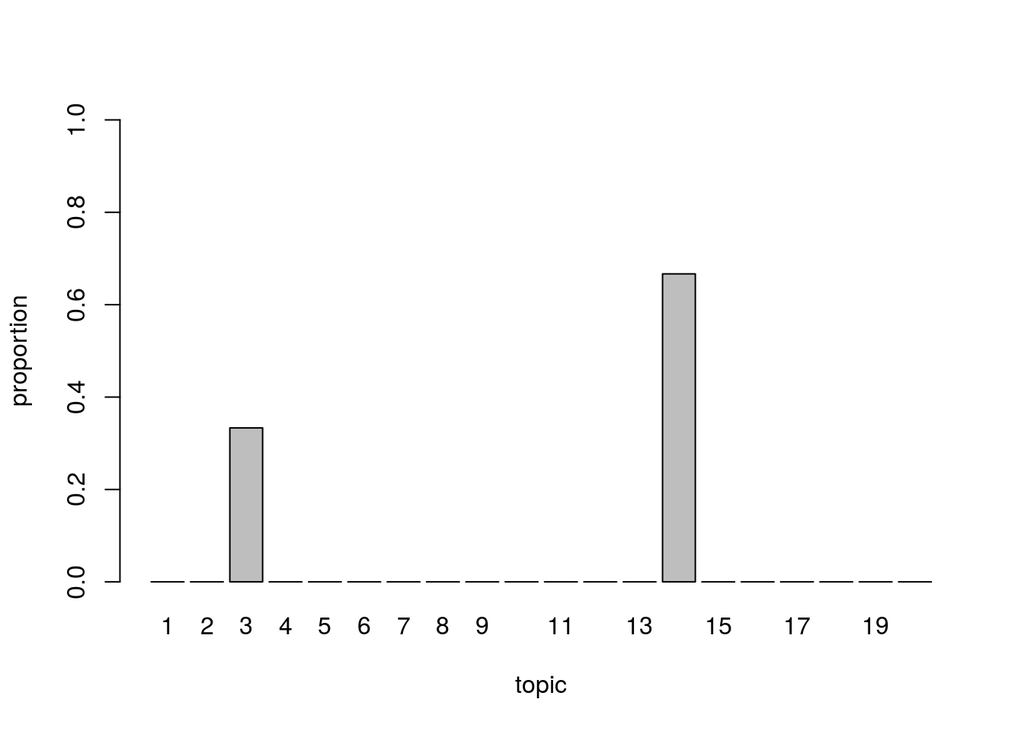

```r
barplot(doc_topic_distr[doc_id, ], xlab = "topic",
        ylab = "proportion", ylim = c(0, 1),
        names.arg = 1:ncol(doc_topic_distr))
```

```r
# to inspect the full topic word matrix use : lda_model$topic_word_distribution
lda_model$get_top_words(n = 10, topic_number = c(9,20), lambda = 1)
```

```
##       [,1]      [,2]
##  [1,] "also"    "good"
##  [2,] "service" "waited"
##  [3,] "stars"   "us"
##  [4,] "sauce"   "hour"
##  [5,] "ever"    "seriously"
##  [6,] "worst"   "come"
##  [7,] "give"    "better"
##  [8,] "bread"   "tables"
##  [9,] "try"     "make"
## [10,] "check"   "beef"
```

### Interactive topic word visualization

A common usecase for LDA is exploration of your dataset, you can discover the hidden structure in your data. You can get a nice interactive visualization of these topics by using the LDAviz package. To do this use the command below. This visualization shows the top words per topic, and also shows which topics are more similar to each other than others. If you have many topics at the same spot you might have too many topics in your model.

```r
lda_model$plot()
```

In some cases reseracher manually label each topic, to ease communication about the model. E.g. topic 1 = ‘service’, topic 2 = ‘food’, topic 3 = ‘price’. If you then use these topics in a downstream classifier you can interpret your results for example as “Reviews which focus on service tend to be more negative than others”.

## 3. Ways to evaluate the fit of your model

As we noted before there are three hyper parameters to tune in your model:

1. The number of topics
2. The document topic distribution prior
3. The topic word distribution prior

Evaluating topic models is difficult because there is no ground truth: we cannot observe the actual topic distribution per document. In practice you will probably find the best solution by manual inspection of the topics. Here you should ask yourself: “are the estimated topics really about one topic?” and “are topics non overlapping?”.

A formal way to optimize the hyper parameters is to minimize the [perplexity](https://en.wikipedia.org/wiki/Perplexity), which is negatively related to the probability of observing documents in the tests set. You can calculate the perplexity on a test set as follows:

```r
# create the dtm of the test set
new_dtm = itoken(alltext[J(test_ids)]$review, tolower, word_tokenizer, ids = alltext[J(test_ids)]$id) %>%
          create_dtm(vectorizer, type = "dgTMatrix")

# estimate the document topic distribution of this new text based on the old model
new_doc_topic_distr = lda_model$transform(new_dtm)

# calculate perplexity
perp <- perplexity(new_dtm, topic_word_distribution = lda_model$topic_word_distribution, doc_topic_distribution = new_doc_topic_distr)

print(perp)
```

[output not shown]

It is then relatively straightforward to try different values of your parameters to find the optimal perplexity. A downside of optimizing for perplexity is that they do not necessarily correspond with human judgements of the optimal model, perplexity tends to overestimate the optimal number of topics. There is reserach on metrics that correspond better with human judgements, but that is beyond the scope of this course. For your project we urge you not inspect but not blindly follow the guidance of the perplexity estimate, definitely also to evaluate the topics yourself.

**Question 1: create a function which calculates the perplexity for different n_topics. Plot your values of n_topics and perplexity. Determine the optimal number of topics.**

### What do the priors do?

To learn what the priors do I suggest you try and answer the following question:

**Question 2: Create a function which calculates the number of non-zero values in the document topic matrix for different values of the doc_topic_prior. Plot your results. Interpret and explain your findings**

Can you now guess what the topic_word_prior does?

## Final Project

Apply the LDA method to your final project data. One good use case is to explore and communicate the hidden structure in your data. Another good use case is to use the topic vectors as input for your classifier, as a replacement of the BoW/TFIDF vectors before.